# Risk Factor Analysis

## Outcome Variable

**Outcome Variable:** stunted

## Predictor Variables

**Intervention Variable:** predfeed6

**Adjustment Set:**

- arm
- sex
- month
- brthmon
- W_mage
- meducyrs
- feducyrs
- hhwealth_quart
- hfoodsec
- W_mhtcm
- vagbrth
- W_gagebrth
- W_birthwt
- W_birthlen
- W_nrooms
- W_nchldlt5
- W_parity
- impfloor
- impsan
- safeh20
- delta_W_mage
- delta_meducyrs
- delta_feducyrs
- delta_hhwealth_quart
- delta_hfoodsec
- delta_W_mhtcm
- delta_vagbrth
- delta_W_gagebrth
- delta_W_birthwt
- delta_W_birthlen
- delta_W_nrooms
- delta_W_nchldlt5
- delta_W_parity
- delta_impfloor
- delta_impsan
- delta_safeh20

## Stratifying Variables

The analysis was stratified on these variable(s):

- agecat
- studyid
- country

## Data Summary

| agecat | studyid | country | predfeed6 | stunted | n_cell | n |
| --- | --- | --- | --- | --- | --- | --- |
| Birth | ki0047075b-MAL-ED | BANGLADESH | 1 | 0 | 101 | 231 |
| Birth | ki0047075b-MAL-ED | BANGLADESH | 1 | 1 | 18 | 231 |
| Birth | ki0047075b-MAL-ED | BANGLADESH | 0 | 0 | 91 | 231 |
| Birth | ki0047075b-MAL-ED | BANGLADESH | 0 | 1 | 21 | 231 |
| Birth | ki0047075b-MAL-ED | BRAZIL | 1 | 0 | 24 | 175 |
| Birth | ki0047075b-MAL-ED | BRAZIL | 1 | 1 | 3 | 175 |
| Birth | ki0047075b-MAL-ED | BRAZIL | 0 | 0 | 134 | 175 |
| Birth | ki0047075b-MAL-ED | BRAZIL | 0 | 1 | 14 | 175 |
| Birth | ki0047075b-MAL-ED | INDIA | 1 | 0 | 10 | 190 |
| Birth | ki0047075b-MAL-ED | INDIA | 1 | 1 | 5 | 190 |
| Birth | ki0047075b-MAL-ED | INDIA | 0 | 0 | 149 | 190 |
| Birth | ki0047075b-MAL-ED | INDIA | 0 | 1 | 26 | 190 |
| Birth | ki0047075b-MAL-ED | NEPAL | 1 | 0 | 21 | 170 |
| Birth | ki0047075b-MAL-ED | NEPAL | 1 | 1 | 2 | 170 |
| Birth | ki0047075b-MAL-ED | NEPAL | 0 | 0 | 131 | 170 |
| Birth | ki0047075b-MAL-ED | NEPAL | 0 | 1 | 16 | 170 |
| Birth | ki0047075b-MAL-ED | PERU | 1 | 0 | 95 | 256 |
| Birth | ki0047075b-MAL-ED | PERU | 1 | 1 | 11 | 256 |
| Birth | ki0047075b-MAL-ED | PERU | 0 | 0 | 132 | 256 |
| Birth | ki0047075b-MAL-ED | PERU | 0 | 1 | 18 | 256 |
| Birth | ki0047075b-MAL-ED | SOUTH AFRICA | 1 | 0 | 1 | 211 |
| Birth | ki0047075b-MAL-ED | SOUTH AFRICA | 1 | 1 | 2 | 211 |
| Birth | ki0047075b-MAL-ED | SOUTH AFRICA | 0 | 0 | 188 | 211 |
| Birth | ki0047075b-MAL-ED | SOUTH AFRICA | 0 | 1 | 20 | 211 |
| Birth | ki0047075b-MAL-ED | TANZANIA, UNITED REPUBLIC OF | 1 | 0 | 1 | 119 |
| Birth | ki0047075b-MAL-ED | TANZANIA, UNITED REPUBLIC OF | 1 | 1 | 0 | 119 |
| Birth | ki0047075b-MAL-ED | TANZANIA, UNITED REPUBLIC OF | 0 | 0 | 102 | 119 |
| Birth | ki0047075b-MAL-ED | TANZANIA, UNITED REPUBLIC OF | 0 | 1 | 16 | 119 |
| Birth | ki1000109-EE | PAKISTAN | 1 | 0 | 1 | 2 |
| Birth | ki1000109-EE | PAKISTAN | 1 | 1 | 0 | 2 |

[output cut: 106 more lines]

The following strata were considered:

- agecat: 24 months, studyid: ki0047075b-MAL-ED, country: BANGLADESH
- agecat: 24 months, studyid: ki0047075b-MAL-ED, country: BRAZIL
- agecat: 24 months, studyid: ki0047075b-MAL-ED, country: INDIA
- agecat: 24 months, studyid: ki0047075b-MAL-ED, country: NEPAL
- agecat: 24 months, studyid: ki0047075b-MAL-ED, country: PERU
- agecat: 24 months, studyid: ki0047075b-MAL-ED, country: SOUTH AFRICA
- agecat: 24 months, studyid: ki0047075b-MAL-ED, country: TANZANIA, UNITED REPUBLIC OF
- agecat: 24 months, studyid: ki1113344-GMS-Nepal, country: NEPAL
- agecat: 24 months, studyid: ki1148112-LCNI-5, country: MALAWI
- agecat: 24 months, studyid: kiGH5241-JiVitA-3, country: BANGLADESH
- agecat: 24 months, studyid: kiGH5241-JiVitA-4, country: BANGLADESH
- agecat: 6 months, studyid: ki0047075b-MAL-ED, country: BANGLADESH
- agecat: 6 months, studyid: ki0047075b-MAL-ED, country: BRAZIL
- agecat: 6 months, studyid: ki0047075b-MAL-ED, country: INDIA
- agecat: 6 months, studyid: ki0047075b-MAL-ED, country: NEPAL
- agecat: 6 months, studyid: ki0047075b-MAL-ED, country: PERU
- agecat: 6 months, studyid: ki0047075b-MAL-ED, country: SOUTH AFRICA
- agecat: 6 months, studyid: ki0047075b-MAL-ED, country: TANZANIA, UNITED REPUBLIC OF
- agecat: 6 months, studyid: ki1000109-EE, country: PAKISTAN
- agecat: 6 months, studyid: ki1000304b-SAS-FoodSuppl, country: INDIA
- agecat: 6 months, studyid: ki1113344-GMS-Nepal, country: NEPAL
- agecat: 6 months, studyid: ki1148112-LCNI-5, country: MALAWI
- agecat: 6 months, studyid: kiGH5241-JiVitA-3, country: BANGLADESH
- agecat: 6 months, studyid: kiGH5241-JiVitA-4, country: BANGLADESH
- agecat: Birth, studyid: ki0047075b-MAL-ED, country: BANGLADESH
- agecat: Birth, studyid: ki0047075b-MAL-ED, country: BRAZIL
- agecat: Birth, studyid: ki0047075b-MAL-ED, country: INDIA
- agecat: Birth, studyid: ki0047075b-MAL-ED, country: NEPAL
- agecat: Birth, studyid: ki0047075b-MAL-ED, country: PERU
- agecat: Birth, studyid: ki0047075b-MAL-ED, country: SOUTH AFRICA
- agecat: Birth, studyid: ki0047075b-MAL-ED, country: TANZANIA, UNITED REPUBLIC OF
- agecat: Birth, studyid: ki1000109-EE, country: PAKISTAN
- agecat: Birth, studyid: kiGH5241-JiVitA-3, country: BANGLADESH
- agecat: Birth, studyid: kiGH5241-JiVitA-4, country: BANGLADESH

### Dropped Strata

Some strata were dropped due to rare outcomes:

- agecat: Birth, studyid: ki0047075b-MAL-ED, country: BRAZIL
- agecat: Birth, studyid: ki0047075b-MAL-ED, country: NEPAL
- agecat: Birth, studyid: ki0047075b-MAL-ED, country: SOUTH AFRICA
- agecat: Birth, studyid: ki0047075b-MAL-ED, country: TANZANIA, UNITED REPUBLIC OF
- agecat: Birth, studyid: ki1000109-EE, country: PAKISTAN
- agecat: 6 months, studyid: ki0047075b-MAL-ED, country: BRAZIL
- agecat: 6 months, studyid: ki0047075b-MAL-ED, country: NEPAL
- agecat: 6 months, studyid: ki0047075b-MAL-ED, country: SOUTH AFRICA
- agecat: 6 months, studyid: ki0047075b-MAL-ED, country: TANZANIA, UNITED REPUBLIC OF
- agecat: 6 months, studyid: ki1000304b-SAS-FoodSuppl, country: INDIA
- agecat: 24 months, studyid: ki0047075b-MAL-ED, country: BRAZIL
- agecat: 24 months, studyid: ki0047075b-MAL-ED, country: SOUTH AFRICA
- agecat: 24 months, studyid: ki0047075b-MAL-ED, country: TANZANIA, UNITED REPUBLIC OF

## Methods Detail

We’re interested in the causal parameters $E[Y_a]$ for all values of $a \in \mathcal{A}$. These parameters represent the mean outcome if, possibly contrary to fact, we intervened to set all units to have $A=a$. Under the randomization and positivity assumptions, these are identified by the statistical parameters $\psi_a=E_W[E_{Y|A,W}(Y|A=a,W)]$. In addition, we’re interested in the mean of $Y$, $E[Y]$ under no intervention (the observed mean). We will estimate these parameters by using SuperLearner to fit the relevant likelihood factors – $E_{Y|A,W}(Y|A=a,W)$ and $p(A=a|W)$, and then updating our likelihood fit using a joint TMLE.

For unadjusted analyses ($W=\{\}$), initial likelihoods were estimated using Lrnr_glm to estimate the simple $E(Y|A)$ and Lrnr_mean to estimate $p(A)$. For adjusted analyses, a small library containing Lrnr_glmnet, Lrnr_xgboost, and Lrnr_mean was used.

Having estimated these parameters, we will then use the delta method to estimate relative risks and attributable risks relative to a prespecified baseline level of $A$.

# Results Detail

## Results Plots

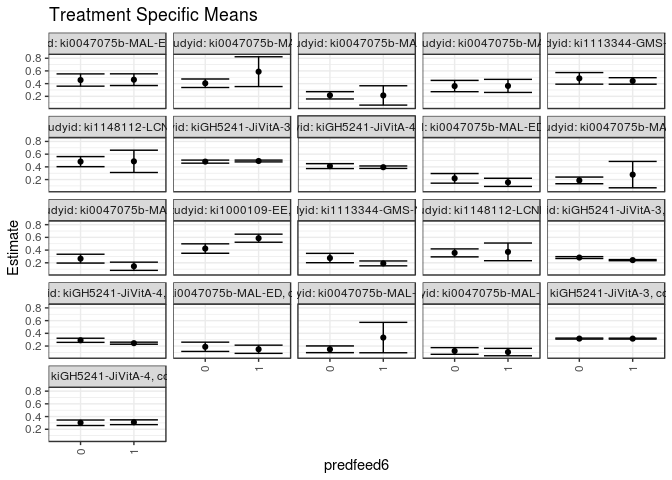

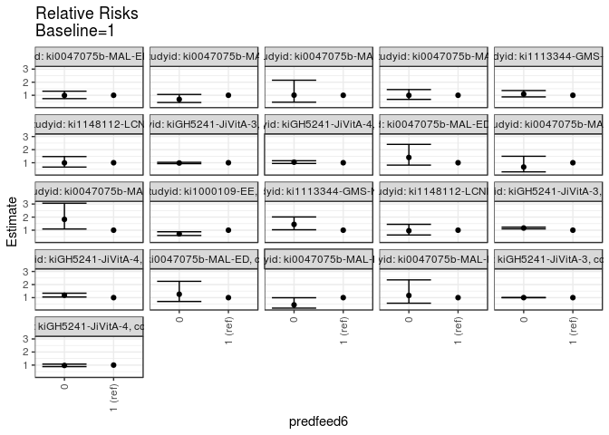

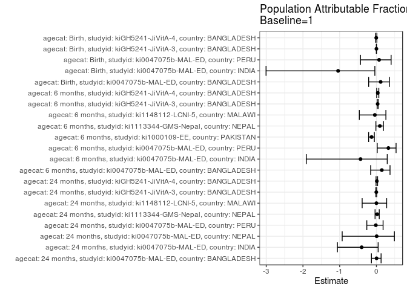

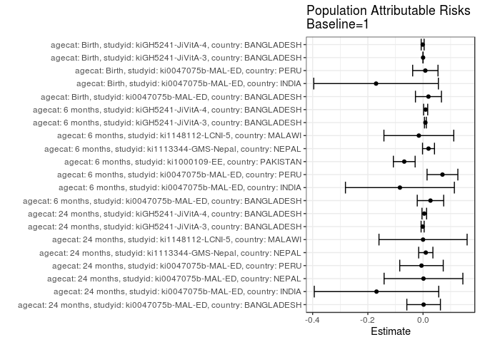

## Results Table

### Parameter: TSM

| agecat | studyid | country | intervention_level | baseline_level | estimate | ci_lower | ci_upper |
| --- | --- | --- | --- | --- | --- | --- | --- |
| Birth | ki0047075b-MAL-ED | BANGLADESH | 1 | NA | 0.1492612 | 0.0847791 | 0.2137434 |
| Birth | ki0047075b-MAL-ED | BANGLADESH | 0 | NA | 0.1880342 | 0.1152936 | 0.2607749 |
| Birth | ki0047075b-MAL-ED | INDIA | 1 | NA | 0.3333333 | 0.0941438 | 0.5725228 |
| Birth | ki0047075b-MAL-ED | INDIA | 0 | NA | 0.1485714 | 0.0957370 | 0.2014058 |
| Birth | ki0047075b-MAL-ED | PERU | 1 | NA | 0.1050102 | 0.0467810 | 0.1632395 |
| Birth | ki0047075b-MAL-ED | PERU | 0 | NA | 0.1223582 | 0.0695855 | 0.1751309 |
| Birth | kiGH5241-JiVitA-3 | BANGLADESH | 1 | NA | 0.3165117 | 0.3089009 | 0.3241224 |
| Birth | kiGH5241-JiVitA-3 | BANGLADESH | 0 | NA | 0.3169683 | 0.3093605 | 0.3245760 |
| Birth | kiGH5241-JiVitA-4 | BANGLADESH | 1 | NA | 0.3103471 | 0.2729069 | 0.3477874 |
| Birth | kiGH5241-JiVitA-4 | BANGLADESH | 0 | NA | 0.3022850 | 0.2589774 | 0.3455926 |
| 6 months | ki0047075b-MAL-ED | BANGLADESH | 1 | NA | 0.1560894 | 0.0917623 | 0.2204166 |
| 6 months | ki0047075b-MAL-ED | BANGLADESH | 0 | NA | 0.2191091 | 0.1431547 | 0.2950636 |
| 6 months | ki0047075b-MAL-ED | INDIA | 1 | NA | 0.2777778 | 0.0704135 | 0.4851421 |
| 6 months | ki0047075b-MAL-ED | INDIA | 0 | NA | 0.1869159 | 0.1345715 | 0.2392603 |
| 6 months | ki0047075b-MAL-ED | PERU | 1 | NA | 0.1452877 | 0.0807383 | 0.2098372 |
| 6 months | ki0047075b-MAL-ED | PERU | 0 | NA | 0.2654111 | 0.1956823 | 0.3351398 |
| 6 months | ki1000109-EE | PAKISTAN | 1 | NA | 0.5869231 | 0.5234000 | 0.6504462 |
| 6 months | ki1000109-EE | PAKISTAN | 0 | NA | 0.4241752 | 0.3500739 | 0.4982766 |
| 6 months | ki1113344-GMS-Nepal | NEPAL | 1 | NA | 0.1908246 | 0.1525470 | 0.2291021 |
| 6 months | ki1113344-GMS-Nepal | NEPAL | 0 | NA | 0.2750261 | 0.2019197 | 0.3481324 |
| 6 months | ki1148112-LCNI-5 | MALAWI | 1 | NA | 0.3717951 | 0.2328454 | 0.5107449 |
| 6 months | ki1148112-LCNI-5 | MALAWI | 0 | NA | 0.3560308 | 0.2932606 | 0.4188009 |
| 6 months | kiGH5241-JiVitA-3 | BANGLADESH | 1 | NA | 0.2422462 | 0.2334888 | 0.2510037 |
| 6 months | kiGH5241-JiVitA-3 | BANGLADESH | 0 | NA | 0.2823892 | 0.2676274 | 0.2971511 |
| 6 months | kiGH5241-JiVitA-4 | BANGLADESH | 1 | NA | 0.2450549 | 0.2289413 | 0.2611685 |
| 6 months | kiGH5241-JiVitA-4 | BANGLADESH | 0 | NA | 0.2903444 | 0.2580010 | 0.3226879 |
| 24 months | ki0047075b-MAL-ED | BANGLADESH | 1 | NA | 0.4620112 | 0.3701458 | 0.5538767 |
| 24 months | ki0047075b-MAL-ED | BANGLADESH | 0 | NA | 0.4562934 | 0.3597113 | 0.5528755 |
| 24 months | ki0047075b-MAL-ED | INDIA | 1 | NA | 0.5882353 | 0.3537610 | 0.8227096 |
| 24 months | ki0047075b-MAL-ED | INDIA | 0 | NA | 0.4057971 | 0.3387537 | 0.4728406 |
| 24 months | ki0047075b-MAL-ED | NEPAL | 1 | NA | 0.2142857 | 0.0619658 | 0.3666056 |
| 24 months | ki0047075b-MAL-ED | NEPAL | 0 | NA | 0.2160804 | 0.1587713 | 0.2733895 |
| 24 months | ki0047075b-MAL-ED | PERU | 1 | NA | 0.3642251 | 0.2612703 | 0.4671799 |
| 24 months | ki0047075b-MAL-ED | PERU | 0 | NA | 0.3617080 | 0.2726636 | 0.4507524 |
| 24 months | ki1113344-GMS-Nepal | NEPAL | 1 | NA | 0.4421652 | 0.3910011 | 0.4933293 |
| 24 months | ki1113344-GMS-Nepal | NEPAL | 0 | NA | 0.4829275 | 0.3917403 | 0.5741147 |
| 24 months | ki1148112-LCNI-5 | MALAWI | 1 | NA | 0.4867656 | 0.3112225 | 0.6623087 |
| 24 months | ki1148112-LCNI-5 | MALAWI | 0 | NA | 0.4822721 | 0.4031320 | 0.5614121 |
| 24 months | kiGH5241-JiVitA-3 | BANGLADESH | 1 | NA | 0.4922174 | 0.4779482 | 0.5064867 |
| 24 months | kiGH5241-JiVitA-3 | BANGLADESH | 0 | NA | 0.4825391 | 0.4583386 | 0.5067395 |
| 24 months | kiGH5241-JiVitA-4 | BANGLADESH | 1 | NA | 0.3946325 | 0.3750713 | 0.4141938 |
| 24 months | kiGH5241-JiVitA-4 | BANGLADESH | 0 | NA | 0.4116615 | 0.3732316 | 0.4500914 |

### Parameter: E(Y)

| agecat | studyid | country | intervention_level | baseline_level | estimate | ci_lower | ci_upper |
| --- | --- | --- | --- | --- | --- | --- | --- |
| Birth | ki0047075b-MAL-ED | BANGLADESH | NA | NA | 0.1688312 | 0.1204189 | 0.2172434 |
| Birth | ki0047075b-MAL-ED | INDIA | NA | NA | 0.1631579 | 0.1104782 | 0.2158376 |
| Birth | ki0047075b-MAL-ED | PERU | NA | NA | 0.1132813 | 0.0743812 | 0.1521813 |
| Birth | kiGH5241-JiVitA-3 | BANGLADESH | NA | NA | 0.3166335 | 0.3090239 | 0.3242430 |
| Birth | kiGH5241-JiVitA-4 | BANGLADESH | NA | NA | 0.3089961 | 0.2722361 | 0.3457561 |
| 6 months | ki0047075b-MAL-ED | BANGLADESH | NA | NA | 0.1829787 | 0.1334386 | 0.2325189 |
| 6 months | ki0047075b-MAL-ED | INDIA | NA | NA | 0.1939655 | 0.1429760 | 0.2449551 |
| 6 months | ki0047075b-MAL-ED | PERU | NA | NA | 0.2156134 | 0.1663773 | 0.2648495 |
| 6 months | ki1000109-EE | PAKISTAN | NA | NA | 0.5188172 | 0.4679751 | 0.5696593 |
| 6 months | ki1113344-GMS-Nepal | NEPAL | NA | NA | 0.2106227 | 0.1763897 | 0.2448557 |
| 6 months | ki1148112-LCNI-5 | MALAWI | NA | NA | 0.3566176 | 0.2995882 | 0.4136471 |
| 6 months | kiGH5241-JiVitA-3 | BANGLADESH | NA | NA | 0.2508093 | 0.2426385 | 0.2589801 |
| 6 months | kiGH5241-JiVitA-4 | BANGLADESH | NA | NA | 0.2545198 | 0.2394884 | 0.2695513 |
| 24 months | ki0047075b-MAL-ED | BANGLADESH | NA | NA | 0.4641148 | 0.3963405 | 0.5318891 |
| 24 months | ki0047075b-MAL-ED | INDIA | NA | NA | 0.4196429 | 0.3548715 | 0.4844143 |
| 24 months | ki0047075b-MAL-ED | NEPAL | NA | NA | 0.2158590 | 0.1622206 | 0.2694975 |
| 24 months | ki0047075b-MAL-ED | PERU | NA | NA | 0.3585859 | 0.2916158 | 0.4255559 |
| 24 months | ki1113344-GMS-Nepal | NEPAL | NA | NA | 0.4520833 | 0.4075129 | 0.4966538 |
| 24 months | ki1148112-LCNI-5 | MALAWI | NA | NA | 0.4867725 | 0.4153250 | 0.5582200 |
| 24 months | kiGH5241-JiVitA-3 | BANGLADESH | NA | NA | 0.4907516 | 0.4775997 | 0.5039035 |
| 24 months | kiGH5241-JiVitA-4 | BANGLADESH | NA | NA | 0.3991375 | 0.3806098 | 0.4176653 |

### Parameter: RR

| agecat | studyid | country | intervention_level | baseline_level | estimate | ci_lower | ci_upper |
| --- | --- | --- | --- | --- | --- | --- | --- |
| Birth | ki0047075b-MAL-ED | BANGLADESH | 1 | 1 | 1.0000000 | 1.0000000 | 1.0000000 |
| Birth | ki0047075b-MAL-ED | BANGLADESH | 0 | 1 | 1.2597658 | 0.7062458 | 2.2471070 |
| Birth | ki0047075b-MAL-ED | INDIA | 1 | 1 | 1.0000000 | 1.0000000 | 1.0000000 |
| Birth | ki0047075b-MAL-ED | INDIA | 0 | 1 | 0.4457143 | 0.2001014 | 0.9928030 |
| Birth | ki0047075b-MAL-ED | PERU | 1 | 1 | 1.0000000 | 1.0000000 | 1.0000000 |
| Birth | ki0047075b-MAL-ED | PERU | 0 | 1 | 1.1652031 | 0.5758579 | 2.3576967 |
| Birth | kiGH5241-JiVitA-3 | BANGLADESH | 1 | 1 | 1.0000000 | 1.0000000 | 1.0000000 |
| Birth | kiGH5241-JiVitA-3 | BANGLADESH | 0 | 1 | 1.0014427 | 1.0005279 | 1.0023583 |
| Birth | kiGH5241-JiVitA-4 | BANGLADESH | 1 | 1 | 1.0000000 | 1.0000000 | 1.0000000 |
| Birth | kiGH5241-JiVitA-4 | BANGLADESH | 0 | 1 | 0.9740222 | 0.8838672 | 1.0733731 |
| 6 months | ki0047075b-MAL-ED | BANGLADESH | 1 | 1 | 1.0000000 | 1.0000000 | 1.0000000 |
| 6 months | ki0047075b-MAL-ED | BANGLADESH | 0 | 1 | 1.4037411 | 0.8192746 | 2.4051630 |
| 6 months | ki0047075b-MAL-ED | INDIA | 1 | 1 | 1.0000000 | 1.0000000 | 1.0000000 |
| 6 months | ki0047075b-MAL-ED | INDIA | 0 | 1 | 0.6728972 | 0.3031666 | 1.4935372 |
| 6 months | ki0047075b-MAL-ED | PERU | 1 | 1 | 1.0000000 | 1.0000000 | 1.0000000 |
| 6 months | ki0047075b-MAL-ED | PERU | 0 | 1 | 1.8267961 | 1.0897406 | 3.0623656 |
| 6 months | ki1000109-EE | PAKISTAN | 1 | 1 | 1.0000000 | 1.0000000 | 1.0000000 |
| 6 months | ki1000109-EE | PAKISTAN | 0 | 1 | 0.7227101 | 0.5940583 | 0.8792233 |
| 6 months | ki1113344-GMS-Nepal | NEPAL | 1 | 1 | 1.0000000 | 1.0000000 | 1.0000000 |
| 6 months | ki1113344-GMS-Nepal | NEPAL | 0 | 1 | 1.4412509 | 1.0324429 | 2.0119314 |
| 6 months | ki1148112-LCNI-5 | MALAWI | 1 | 1 | 1.0000000 | 1.0000000 | 1.0000000 |
| 6 months | ki1148112-LCNI-5 | MALAWI | 0 | 1 | 0.9575994 | 0.6331296 | 1.4483553 |
| 6 months | kiGH5241-JiVitA-3 | BANGLADESH | 1 | 1 | 1.0000000 | 1.0000000 | 1.0000000 |
| 6 months | kiGH5241-JiVitA-3 | BANGLADESH | 0 | 1 | 1.1657115 | 1.1017215 | 1.2334182 |
| 6 months | kiGH5241-JiVitA-4 | BANGLADESH | 1 | 1 | 1.0000000 | 1.0000000 | 1.0000000 |
| 6 months | kiGH5241-JiVitA-4 | BANGLADESH | 0 | 1 | 1.1848138 | 1.0481054 | 1.3393536 |
| 24 months | ki0047075b-MAL-ED | BANGLADESH | 1 | 1 | 1.0000000 | 1.0000000 | 1.0000000 |
| 24 months | ki0047075b-MAL-ED | BANGLADESH | 0 | 1 | 0.9876241 | 0.7434215 | 1.3120435 |
| 24 months | ki0047075b-MAL-ED | INDIA | 1 | 1 | 1.0000000 | 1.0000000 | 1.0000000 |
| 24 months | ki0047075b-MAL-ED | INDIA | 0 | 1 | 0.6898551 | 0.4480893 | 1.0620652 |
| 24 months | ki0047075b-MAL-ED | NEPAL | 1 | 1 | 1.0000000 | 1.0000000 | 1.0000000 |
| 24 months | ki0047075b-MAL-ED | NEPAL | 0 | 1 | 1.0083752 | 0.4721996 | 2.1533703 |
| 24 months | ki0047075b-MAL-ED | PERU | 1 | 1 | 1.0000000 | 1.0000000 | 1.0000000 |
| 24 months | ki0047075b-MAL-ED | PERU | 0 | 1 | 0.9930891 | 0.6860977 | 1.4374426 |
| 24 months | ki1113344-GMS-Nepal | NEPAL | 1 | 1 | 1.0000000 | 1.0000000 | 1.0000000 |
| 24 months | ki1113344-GMS-Nepal | NEPAL | 0 | 1 | 1.0921880 | 0.8756619 | 1.3622547 |
| 24 months | ki1148112-LCNI-5 | MALAWI | 1 | 1 | 1.0000000 | 1.0000000 | 1.0000000 |
| 24 months | ki1148112-LCNI-5 | MALAWI | 0 | 1 | 0.9907687 | 0.6666651 | 1.4724374 |
| 24 months | kiGH5241-JiVitA-3 | BANGLADESH | 1 | 1 | 1.0000000 | 1.0000000 | 1.0000000 |
| 24 months | kiGH5241-JiVitA-3 | BANGLADESH | 0 | 1 | 0.9803373 | 0.9296519 | 1.0337860 |
| 24 months | kiGH5241-JiVitA-4 | BANGLADESH | 1 | 1 | 1.0000000 | 1.0000000 | 1.0000000 |
| 24 months | kiGH5241-JiVitA-4 | BANGLADESH | 0 | 1 | 1.0431514 | 0.9448377 | 1.1516950 |

### Parameter: PAR

| agecat | studyid | country | intervention_level | baseline_level | estimate | ci_lower | ci_upper |
| --- | --- | --- | --- | --- | --- | --- | --- |
| Birth | ki0047075b-MAL-ED | BANGLADESH | 1 | NA | 0.0195699 | -0.0275192 | 0.0666591 |
| Birth | ki0047075b-MAL-ED | INDIA | 1 | NA | -0.1701754 | -0.3959039 | 0.0555530 |
| Birth | ki0047075b-MAL-ED | PERU | 1 | NA | 0.0082710 | -0.0376044 | 0.0541465 |
| Birth | kiGH5241-JiVitA-3 | BANGLADESH | 1 | NA | 0.0001218 | 0.0000528 | 0.0001908 |
| Birth | kiGH5241-JiVitA-4 | BANGLADESH | 1 | NA | -0.0013511 | -0.0067353 | 0.0040332 |
| 6 months | ki0047075b-MAL-ED | BANGLADESH | 1 | NA | 0.0268893 | -0.0209914 | 0.0747700 |
| 6 months | ki0047075b-MAL-ED | INDIA | 1 | NA | -0.0838123 | -0.2811128 | 0.1134882 |
| 6 months | ki0047075b-MAL-ED | PERU | 1 | NA | 0.0703256 | 0.0145649 | 0.1260864 |
| 6 months | ki1000109-EE | PAKISTAN | 1 | NA | -0.0681059 | -0.1075419 | -0.0286698 |
| 6 months | ki1113344-GMS-Nepal | NEPAL | 1 | NA | 0.0197982 | -0.0018750 | 0.0414713 |
| 6 months | ki1148112-LCNI-5 | MALAWI | 1 | NA | -0.0151775 | -0.1417053 | 0.1113504 |
| 6 months | kiGH5241-JiVitA-3 | BANGLADESH | 1 | NA | 0.0085630 | 0.0052691 | 0.0118570 |
| 6 months | kiGH5241-JiVitA-4 | BANGLADESH | 1 | NA | 0.0094649 | 0.0020659 | 0.0168640 |
| 24 months | ki0047075b-MAL-ED | BANGLADESH | 1 | NA | 0.0021036 | -0.0587133 | 0.0629206 |
| 24 months | ki0047075b-MAL-ED | INDIA | 1 | NA | -0.1685924 | -0.3940445 | 0.0568596 |
| 24 months | ki0047075b-MAL-ED | NEPAL | 1 | NA | 0.0015733 | -0.1410968 | 0.1442434 |
| 24 months | ki0047075b-MAL-ED | PERU | 1 | NA | -0.0056393 | -0.0844369 | 0.0731584 |
| 24 months | ki1113344-GMS-Nepal | NEPAL | 1 | NA | 0.0099181 | -0.0158535 | 0.0356898 |
| 24 months | ki1148112-LCNI-5 | MALAWI | 1 | NA | 0.0000069 | -0.1596267 | 0.1596405 |
| 24 months | kiGH5241-JiVitA-3 | BANGLADESH | 1 | NA | -0.0014658 | -0.0070525 | 0.0041208 |
| 24 months | kiGH5241-JiVitA-4 | BANGLADESH | 1 | NA | 0.0045050 | -0.0038599 | 0.0128699 |

### Parameter: PAF

| agecat | studyid | country | intervention_level | baseline_level | estimate | ci_lower | ci_upper |
| --- | --- | --- | --- | --- | --- | --- | --- |
| Birth | ki0047075b-MAL-ED | BANGLADESH | 1 | NA | 0.1159142 | -0.2106944 | 0.3544137 |
| Birth | ki0047075b-MAL-ED | INDIA | 1 | NA | -1.0430108 | -3.0048977 | -0.0421971 |
| Birth | ki0047075b-MAL-ED | PERU | 1 | NA | 0.0730132 | -0.4335668 | 0.4005829 |
| Birth | kiGH5241-JiVitA-3 | BANGLADESH | 1 | NA | 0.0003848 | 0.0001664 | 0.0006030 |
| Birth | kiGH5241-JiVitA-4 | BANGLADESH | 1 | NA | -0.0043724 | -0.0219285 | 0.0128821 |
| 6 months | ki0047075b-MAL-ED | BANGLADESH | 1 | NA | 0.1469531 | -0.1564576 | 0.3707603 |
| 6 months | ki0047075b-MAL-ED | INDIA | 1 | NA | -0.4320988 | -1.9096862 | 0.2951450 |
| 6 months | ki0047075b-MAL-ED | PERU | 1 | NA | 0.3261655 | 0.0224971 | 0.5354971 |
| 6 months | ki1000109-EE | PAKISTAN | 1 | NA | -0.1312714 | -0.2114059 | -0.0564379 |
| 6 months | ki1113344-GMS-Nepal | NEPAL | 1 | NA | 0.0939982 | -0.0142062 | 0.1906584 |
| 6 months | ki1148112-LCNI-5 | MALAWI | 1 | NA | -0.0425595 | -0.4652662 | 0.2582028 |
| 6 months | kiGH5241-JiVitA-3 | BANGLADESH | 1 | NA | 0.0341415 | 0.0208900 | 0.0472137 |
| 6 months | kiGH5241-JiVitA-4 | BANGLADESH | 1 | NA | 0.0371874 | 0.0078024 | 0.0657022 |
| 24 months | ki0047075b-MAL-ED | BANGLADESH | 1 | NA | 0.0045326 | -0.1355373 | 0.1273246 |
| 24 months | ki0047075b-MAL-ED | INDIA | 1 | NA | -0.4017522 | -1.0618527 | 0.0470176 |
| 24 months | ki0047075b-MAL-ED | NEPAL | 1 | NA | 0.0072886 | -0.9318486 | 0.4898793 |
| 24 months | ki0047075b-MAL-ED | PERU | 1 | NA | -0.0157264 | -0.2611101 | 0.1819111 |
| 24 months | ki1113344-GMS-Nepal | NEPAL | 1 | NA | 0.0219388 | -0.0367724 | 0.0773252 |
| 24 months | ki1148112-LCNI-5 | MALAWI | 1 | NA | 0.0000142 | -0.3880965 | 0.2796095 |
| 24 months | kiGH5241-JiVitA-3 | BANGLADESH | 1 | NA | -0.0029869 | -0.0144363 | 0.0083332 |
| 24 months | kiGH5241-JiVitA-4 | BANGLADESH | 1 | NA | 0.0112868 | -0.0098482 | 0.0319794 |